# Series de Tiempo Univariadas

Wilson Sandoval Rodriguez

2025-02-17

Para hacer inferencias estadísticas en la estructura de un proceso estocástico (o serie de tiempo) sobre el histórico observado del proceso, normalmente se deben hacer algunas suposiciones simplificadoras (presumiblemente razonables) sobre esa estructura. El supuesto más importante es el de **estacionariedad**.

Dicho concepto tendrá dos versiones:

- Estacionariedad fuerte
- Estacionariedad débil

## Estacionariedad Fuerte y Débil.

Una serie de tiempo se puede ver como un proceso estocástico, se dice que es estacionario si su media y varianza son constantes en el tiempo y si el valor de la covarianza entre 2 periodos depende sólo de la distancia o rezago entre los tiempos.

Sea $Y_t$ una serie de tiempo con las siguientes propiedades se dice que es debilmente estacionaria o simplemente estacionaria:

- $E(y_t)$ es constante para todo $t$.
- $Var(y_t)$ es constante para todo $t$ y,
- $Cov(y_t,y_{t+h})$ sólo depende de $h$ para cualquier $t$

La condición adicional para que una serie de tiempo sea fuertemente estacionaria es que la distribución conjunta de $Y_{t_1},Y_{t_2}, \cdots, Y_{t_n}$ es la misma que la distribución conjunta de $Y_{t_1-k}, Y_{t_2-k}, \cdots, Y_{t_n-k}$ para todas las opciones de puntos de tiempo $t_1, t_2, \cdots, t_n$ y todas las opciones de rezago temporal $k$. es decir, la distribución sólo depende de la diferencia de tiempo $h$ y no del tiempo $(t_1,...,t_k)$

*En la práctica, buscamos que los datos sean estacionarios para poder proseguir con el tratamiento estadístico de los mismos.*

**La estacionariedad es un concepto fundamental para el análisis de las series de tiempo.**

- La estacionariedad significa que el proceso mediante el cual se crearon los datos, es constante en el tiempo.
- **CUIDADO**: Esto no significa que los datos no puedan cambiar. Significa que los supuestos distribucionales del mecanismo que genera los datos son constantes en el tiempo.
- El punto de partida de la metodología Box-Jenkins es la estacionariedad. De ahí su importancia práctica.

## Librerias

```r
library(foreign)
library(ggfortify)
library(forecast)
library(gridExtra)
library(seasonal)
library(lattice)
library(zoo)
#library(urca)
library(dynlm)
library(TSstudio)
```

## Asi se ve la no estacionariedad

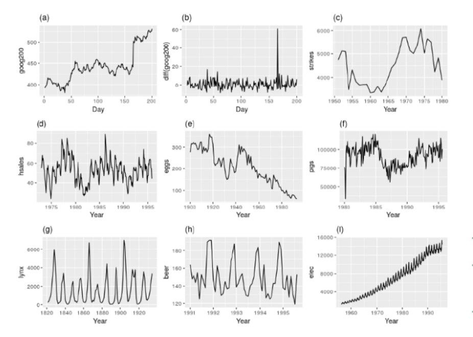

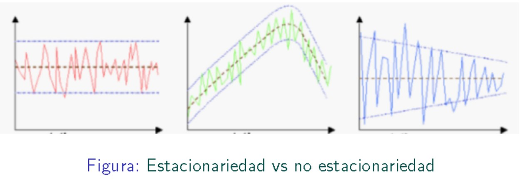

Estacionariedad vs no estacionariedad

## **RUIDO BLANCO**

El objetivo de las Series Temporales es descomponer la serie observada en dos partes: una es la parte dependiente del pasado y la otra la parte impredecible

$$Y_t=f(Y_{(t-1)}, Y_{(t-2)},....,Y_1)+
a_t$$

- Si todas las series que observamos en la realidad fuesen Ruido Blanco serían impredecibles y no habría ningún modelo que proponer.

Un **Ruido Blanco** es una serie tal que su media es cero, la varianza es constante y es incorrelacionada.

- $E(a_t)=0$
- $Var(a_t)=\sigma_a^2$
- $cov(a_t,a_{t+_h})=0$

Se trata de un proceso en el que todas sus variables son independientes.

## Así se ve un Ruido Blanco

Generamos los datos

```r
ruido_blanco=rnorm(1000,0,1)
```

Graficamos la serie de tiempo

```r
ts_plot(ts(ruido_blanco),title = "Ruido Blanco", Xtitle = "Tiempo", Ytitle = "Valore",color = "red")
```

[interactive chart not shown]

Otra forma de simular ruido blanco

```r
set.seed(123)
ruido_blanco1 = arima.sim(n = 1000,
                         list(order = c(0,0,0)))
ts_plot(ruido_blanco1)
```

[interactive chart not shown]

## **MODELOS**

Uno de los modelos de tipo ARIMA más simples es un modelo en el que utilizamos un modelo lineal para predecir el valor en el momento actual utilizando el valor en el momento anterior. Esto se llama un modelo *AR (1)* , que significa modelo autorregresivo de orden 1 .

- El orden del modelo indica cuántas veces anteriores usamos para predecir el tiempo presente.

## Modelo **AR($1$)**

teóricamente, el modelo **AR ($1$)** está escrito

$$x_t = \delta + \phi_1 x_{t-1} +
w_t$$

- $w_t \overset{iid}{\sim} N(0, \sigma^2_w)$ lo que significa que los errores se distribuyen independientemente con una distribución normal que tiene media 0 y varianza constante
- Propiedades de los errores. $w_t$ son independientes de $x$.

### **AR(2)**

$$x_t = \delta + \phi_1 x_{t-1}+ \phi_2
x_{t-2} + w_t$$

### **AR($p$)**

$$x_t = \delta + \phi_1 x_{t-1}+ \phi_2
x_{t-2}+ \cdots\phi_{p}x_{t-p} + w_t$$

## **Función de autocorrelación (ACF)**

El **ACF** de la serie da correlaciones entre $x_t$ y $x_{t-h}$ para $h= 1, 2, 3$, etc.

**Definición Formal:**

La **Función de Autocorrelación** $\rho_k$ en un retardo $k$ es una medida de la correlación entre los valores de una serie de tiempo $\{X_t\}$ y los valores de la misma serie en retardos $k$, es decir, entre $X_t$ y $X_{t-k}$. Matemáticamente, la ACF en un retardo $k$ se define como:

$$\rho_k = \frac{\text{Cov}(X_t, X_{t-k})}{\text{Var}(X_t)}$$

donde:

- $\text{Cov}(X_t, X_{t-k})$ es la covarianza entre $X_t$ y $X_{t-k}$.
- $\text{Var}(X_t)$ es la varianza de la serie de tiempo.

Para una serie temporal estacionaria, la ACF depende solo del retardo $k$ y no del tiempo $t$.

**Propiedades:** - $\rho_0 = 1$, porque la autocorrelación en el retardo cero es la correlación de la serie consigo misma.

- $\rho_k$ es simétrica respecto a $k$, es decir, $\rho_k = \rho_{-k}$.
- La ACF es útil para identificar el orden del proceso MA (Media Móvil).

```r
AirPassengers
```

```
##      Jan Feb Mar Apr May Jun Jul Aug Sep Oct Nov Dec
## 1949 112 118 132 129 121 135 148 148 136 119 104 118
## 1950 115 126 141 135 125 149 170 170 158 133 114 140
## 1951 145 150 178 163 172 178 199 199 184 162 146 166
## 1952 171 180 193 181 183 218 230 242 209 191 172 194
## 1953 196 196 236 235 229 243 264 272 237 211 180 201
## 1954 204 188 235 227 234 264 302 293 259 229 203 229
## 1955 242 233 267 269 270 315 364 347 312 274 237 278
## 1956 284 277 317 313 318 374 413 405 355 306 271 306
## 1957 315 301 356 348 355 422 465 467 404 347 305 336
## 1958 340 318 362 348 363 435 491 505 404 359 310 337
## 1959 360 342 406 396 420 472 548 559 463 407 362 405
## 1960 417 391 419 461 472 535 622 606 508 461 390 432
```

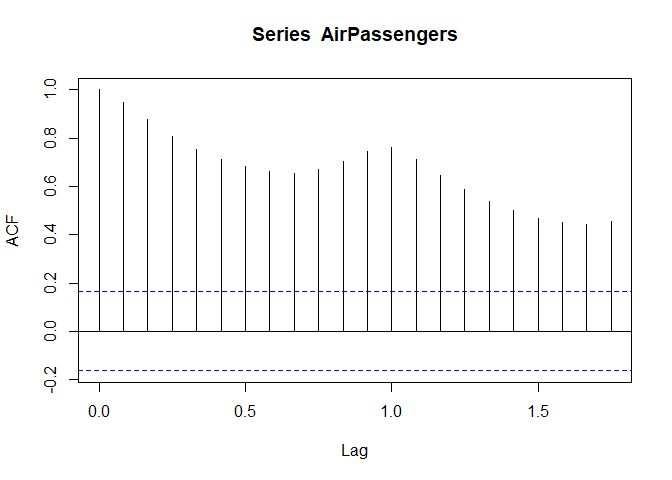

```r
acf(AirPassengers)
```

```r
ts_cor(ruido_blanco1)
```

[interactive chart not shown]

## Función de autocorrelación parcial PACF

En general, una correlación parcial es una correlación condicional. Es la correlación entre dos variables bajo el supuesto de que conocemos y tenemos en cuenta los valores de algún otro conjunto de variables.

**Definición Formal:**

La **Función de Autocorrelación Parcial** $\phi_{kk}$ en un retardo $k$ mide la correlación entre $X_t$ y $X_{t-k}$ después de eliminar el efecto de las autocorrelaciones de todos los retardos menores (1, 2, …, $k-1$). Se define como la autocorrelación entre $X_t$ y $X_{t-k}$ condicionada a $X_{t-1}, X_{t-2}, \dots, X_{t-(k-1)}$.

Matemáticamente, para una serie estacionaria $\{X_t\}$, la PACF en el retardo $k$ está definida por la siguiente relación de recursión:

$$\phi_{kk} = \frac{\text{Cov}(X_t - \hat{X}_{t|t-1,\dots,t-(k-1)},
X_{t-k} - \hat{X}_{t-k|t-k+1,\dots,t-(k-1)})}{\sqrt{\text{Var}(X_t -
\hat{X}_{t|t-1,\dots,t-(k-1)}) \cdot \text{Var}(X_{t-k} -
\hat{X}_{t-k|t-k+1,\dots,t-(k-1)})}}$$

donde $\hat{X}_{t|t-1,\dots,t-(k-1)}$ es la mejor predicción lineal de $X_t$ basada en las observaciones $X_{t-1}, X_{t-2}, \dots, X_{t-(k-1)}$.

**Propiedades:**

- La PACF en el retardo $k = 1$ es simplemente la ACF en $k = 1$.
- La PACF puede ser utilizada para identificar el orden del proceso AR (Autorregresivo).

Para una serie temporal, la autocorrelación parcial entre $x_t$ y $x_{t-h}$ se define como la correlación condicional entre $x_t$ y $x_{t-h}$ condicionado a $x_{t-h+1}$ , …,$x_{t-1}$ , el conjunto de observaciones que se encuentran entre los puntos de tiempo $t$ y $t-h$

- La autocorrelación parcial de primer orden se definirá para que sea igual a la autocorrelación de primer orden.
- El 2nd autocorrelación parcial orden (lag) es

$$\dfrac{\text{Cov}(x_t, x_{t-2}|
x_{t-1})}{\sqrt{\text{Var}(x_t|x_{t-1})\text{Var}(x_{t-2}|x_{t-1})}}$$

### Cálculo de $\phi_{22}$ usando las Ecuaciones de Yule-Walker

1. **Expresión General de Yule-Walker:**

   $$\rho_i = \phi_{j1} \rho_{i-1} + \phi_{j2} \rho_{i-2} + \dots + \phi_{jj}
   \rho_{i-j}$$
2. **Cálculo de $\phi_{11}$:**

   Para $j = 1$ y $i = 1$:

   $$\rho_1 = \phi_{11}$$
3. **Cálculo de $\phi_{22}$:**

   Se establece un sistema de ecuaciones para $j = 2$:
   - Para $i = 1$:

     $$\rho_1 = \phi_{21} + \phi_{22} \rho_1$$
   - Para $i = 2$:

     $$\rho_2 = \phi_{21} \rho_1 + \phi_{22}$$

   Estas ecuaciones se pueden expresar en forma matricial:

   $$\begin{pmatrix}
   \rho_1 \\
   \rho_2
   \end{pmatrix}
   =
   \begin{pmatrix}
   1 & \rho_1 \\
   \rho_1 & 1
   \end{pmatrix}
   \begin{pmatrix}
   \phi_{21} \\
   \phi_{22}
   \end{pmatrix}$$
4. **Resolución por la Regla de Cramer:**

**Nota:** Calcular manualmente la Función de Autocorrelación Parcial (PACF) puede ser un proceso complejo. Esto se debe a que, para cada retardo, es necesario ajustar la correlación entre las observaciones eliminando la influencia de todos los retardos anteriores. Este ajuste se realiza resolviendo sistemas de ecuaciones lineales, frecuentemente utilizando las ecuaciones de Yule-Walker.

## Propiedades de la AR (1)

- La media (teórica) de $x_t$ es: $E(x_t)=\mu = \dfrac{\delta}{1-\phi_1}$
- La varianza de $x_t$ es: $\text{Var}(x_t) = \dfrac{\sigma^2_w}{1-\phi_1^2}$
- La correlación $h$ entre observaciones períodos de tiempo separados es $\rho_h = \phi^h_1$

¡Nota! $\phi_1$ es la pendiente en el modelo **AR ($1$)** y ahora vemos que también es la autocorrelación de retraso 1

## Simular modelo autoregresivo AR($1$) con $\phi$ = 0.5

$$y_t = 0.5 * y_{t-1} + w_t$$

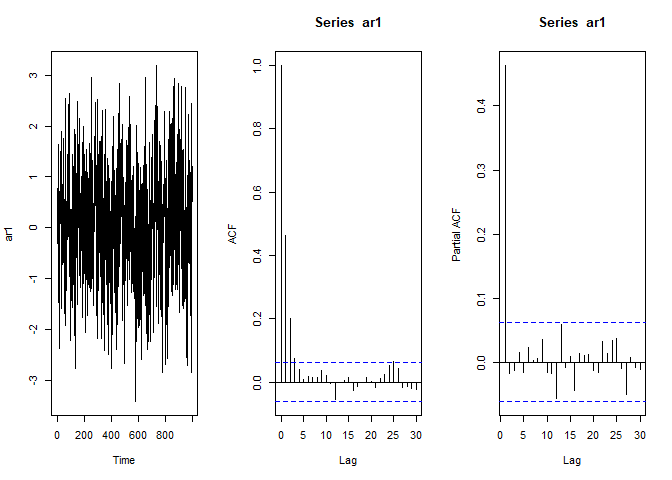

```r
set.seed(123)
ar1 = arima.sim(n = 1000, list(ar = 0.5))
par(mfrow = c(1,3))
plot(ar1)
acf(ar1)
pacf(ar1)
```

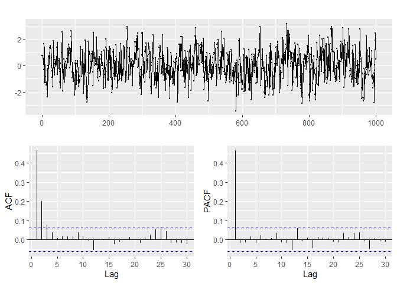

```r
ggtsdisplay(ar1)
```

```r
library(TSstudio)
ts_cor(ar1)
```

[interactive chart not shown]

### simular un AR($1$) serie autoregresiva con $\phi$ = -0.9

El modelo es:
$$y_t = -0.9 * y_{t-1} +
w_t$$

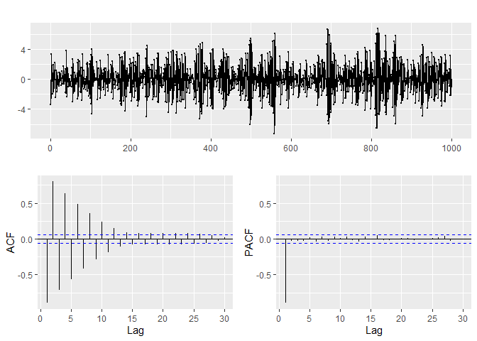

```r
set.seed(123)
ar2 = arima.sim(n = 1000, list(ar = -0.9))
ggtsdisplay(ar2)
```

```r
ts_cor(ar2)
```

[interactive chart not shown]

### Otra simulación con $\phi=0.1$

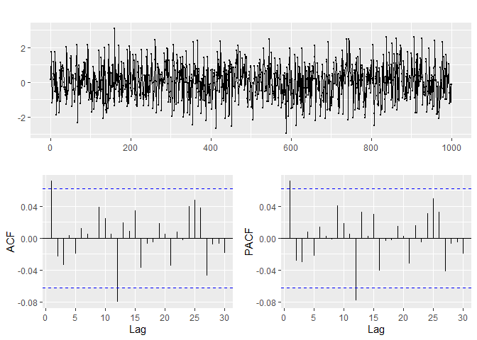

```r
set.seed(123)
ar3 = arima.sim(n = 1000, list(ar = 0.1))
ggtsdisplay(ar3)
```

```r
ts_cor(ar3)
```

[interactive chart not shown]

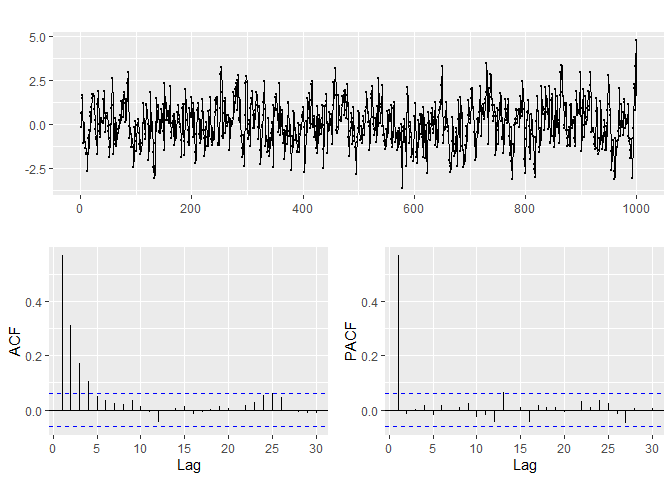

```r
set.seed(123)
ar4 = arima.sim(n = 1000, list(ar = 0.6))
ggtsdisplay(ar4)
```

```r
ts_cor(ar4)
```

[interactive chart not shown]

## **Simulaciones de un de un AR(2)**

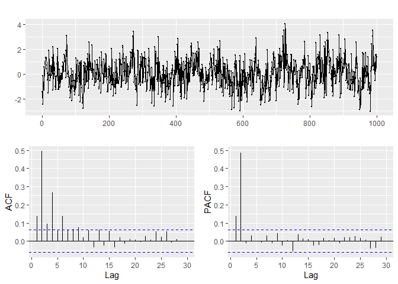

```r
set.seed(123)
ar5 = arima.sim(n = 1000, list(ar = c(0.1,0.5)))
ggtsdisplay(ar5)
```

```r
ts_cor(ar5)
```

[interactive chart not shown]

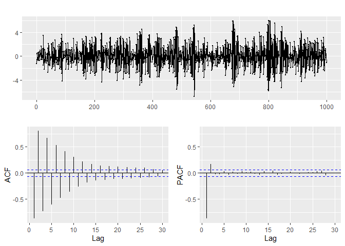

```r
set.seed(123)
ar6 = arima.sim(n = 1000, list(ar =c(-0.7, 0.2)))
ggtsdisplay(ar6)
```

## **Modelos de media móvil (MA)**

### MA($1$)

$$x_t = \mu + w_t
-\theta_1w_{t-1}$$

$w_t \overset{iid}{\sim} N(0, \sigma^2_w)$

### MA(2)

$$x_t = \mu + w_t
+\theta_1w_{t-1}+\theta_2w_{t-2}$$

$w_t \overset{iid}{\sim} N(0, \sigma^2_w)$

### MA(q)

$$x_t = \mu + w_t
+\theta_1w_{t-1}+\theta_2w_{t-2}+\dots + \theta_qw_{t-q}$$

¡Nota! Muchos libros de texto y programas de software definen el modelo con signos negativos antes de $\theta$. Esto no cambia las propiedades teóricas generales del modelo, aunque sí cambia los signos algebraicos de los valores de coeficientes estimados y (no cuadrado)términos en fórmulas para ACF y variaciones.

## Propiedades teóricas de una serie temporal con un modelo MA ($1$)

- La media es $E(x_t)=\mu$
- La varianza es $Var(x_t)= \sigma^2_w(1+\theta^2_1)$
- La función de autocorrelación (ACF) es: $\rho_1 = \dfrac{\theta_1}{1+\theta^2_1}, \text{ and } \rho_h = 0 \text{ for } h \ge 2$

Nota! Que el único valor distinto de cero en el ACF teórico es para el retraso 1 . Todas las demás autocorrelaciones son 0. Por lo tanto, una muestra de ACF con una autocorrelación significativa solo en el retraso 1 es un indicador de un posible modelo de MA ($1$).}

## Simulaciones $1$

#### MA($1$) con $\theta=0.7$

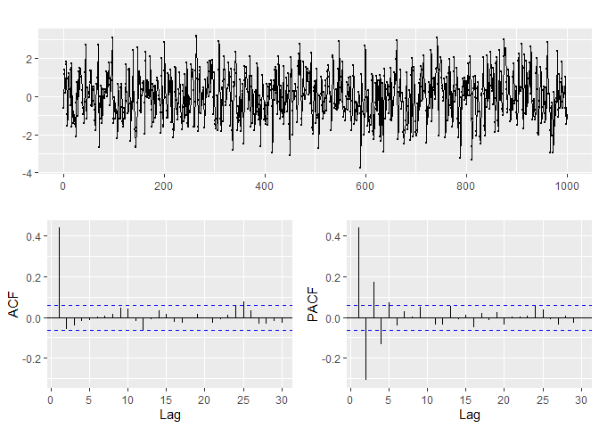

```r
set.seed(123)
ma1 = arima.sim(n = 1000, list(ma =0.7))
ggtsdisplay(ma1)
```

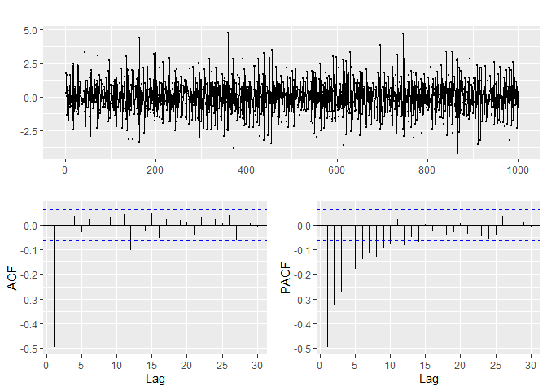

```r
set.seed(123)
ma2 = arima.sim(n = 1000, list(ma =-0.9))
ggtsdisplay(ma2)
```

#### MA(2)

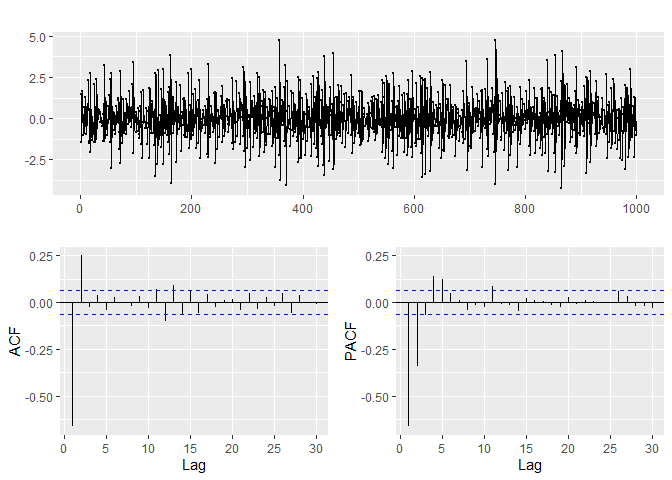

```r
set.seed(123)
ma3 = arima.sim(n = 1000, list(ma =c(-0.9,0.5)))
ggtsdisplay(ma3)
```

## Modelos de media móvil autorregresiva (ARMA)

Al combinar los dos modelos **MA** y **AR**, obtenemos lo que se llama un modelo de promedio móvil autoregresivo **(ARMA)**.

El caso más simple, es el proceso **ARMA ($1$,$1$)** como

$$\begin{equation}
y_{t}=\phi y_{t-1}+\varepsilon_{t}+\theta \varepsilon_{t-1}
\tag{3.1}
\end{equation}$$

En la discusión relacionada con los procesos de promedio móvil, notamos que el **ACF** daría una indicación del orden del proceso, mientras que el **PACF** disminuiría lentamente. En contraste, cuando discutimos los modelos autoregresivos, notamos que el **PACF** daría una indicación del orden del proceso, mientras que el **ACF** disminuiría lentamente.

Cuando consideramos el proceso *ARMA* combinado, generalmente notamos que ambas funciones deberían decaer ligeramente y, como tal, puede ser difícil descifrar el orden del modelo ARMA combinado.

## Algunas librerias

```r
library(foreign)
library(ggfortify)
library(forecast)
library(gridExtra)
library(seasonal)
library(lattice)
library(zoo)
library(urca)
library(dynlm)
```

## Simulación ARMA($1,1$)

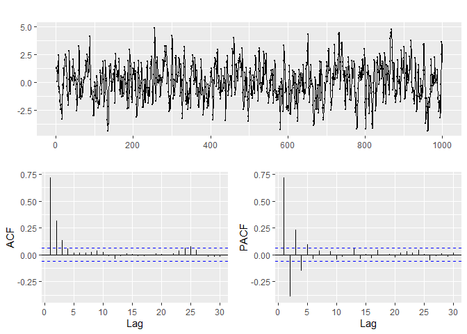

```r
set.seed(123)
arma1 = arima.sim(n = 1000, list(ar = 0.5,ma=0.7))
ggtsdisplay(arma1)
```

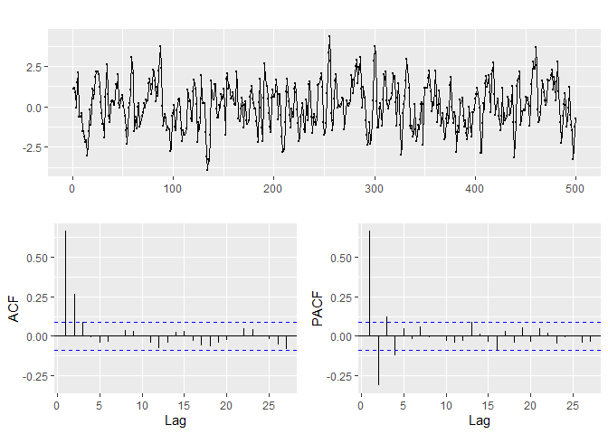

```r
set.seed(123)
arma1 = arima.sim(n = 500, list(ar = 0.5,ma=0.5))
ggtsdisplay(arma1)
```

Los modelos **ARMA** (incluidos los términos AR y MA) tienen *ACF* y *PACF* que ambos se reducen a 0. Estos son los más complicados porque el orden no será particularmente obvio. Básicamente, solo tiene que adivinar que uno o dos términos de cada tipo pueden ser necesarios y luego ver qué sucede cuando estima el modelo.

## ARMA(p,q)

$$\begin{equation}
y_{t}=\phi_1 y_{t-1}+ \phi_2 y_{t-2}+ \cdots\phi_p y_{t-p} +
\varepsilon_{t}+\theta_1 \varepsilon_{t-1}+ \theta_2 \varepsilon_{t-2}+
\cdots+ \theta_q \varepsilon_{t-q}
\end{equation}$$

## Diferenciación

A menudo, la diferenciación se usa para dar cuenta de la no estacionariedad que ocurre en forma de tendencia y / o estacionalidad.

La diferencia $x_t-x_{t-1}$ puede expresarse como $(1-B)x_{t}$.

Una notación alternativa para una diferencia es

$$(\boldsymbol{1-B})=\triangle$$

Así
$$\triangle x_t =
\boldsymbol{(1-B)}x_t = x_t-x_{t-1}$$

Un superindice define una diferencia de retraso igual al subíndice. Por ejemplo,

$$\triangle^{12} x_t =
(\boldsymbol{1-B}^{12})x_t = x_t-x_{t-12}$$

Este tipo de diferencia a menudo se usa con datos mensuales que exhiben estacionalidad

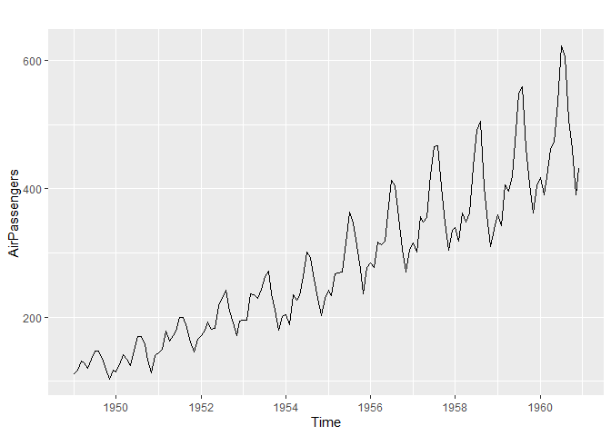

```r
data("AirPassengers")
autoplot(AirPassengers)
```

```r
AirPassengers
```

```
##      Jan Feb Mar Apr May Jun Jul Aug Sep Oct Nov Dec
## 1949 112 118 132 129 121 135 148 148 136 119 104 118
## 1950 115 126 141 135 125 149 170 170 158 133 114 140
## 1951 145 150 178 163 172 178 199 199 184 162 146 166
## 1952 171 180 193 181 183 218 230 242 209 191 172 194
## 1953 196 196 236 235 229 243 264 272 237 211 180 201
## 1954 204 188 235 227 234 264 302 293 259 229 203 229
## 1955 242 233 267 269 270 315 364 347 312 274 237 278
## 1956 284 277 317 313 318 374 413 405 355 306 271 306
## 1957 315 301 356 348 355 422 465 467 404 347 305 336
## 1958 340 318 362 348 363 435 491 505 404 359 310 337
## 1959 360 342 406 396 420 472 548 559 463 407 362 405
## 1960 417 391 419 461 472 535 622 606 508 461 390 432
```

```r
diff(AirPassengers)
```

```
##       Jan  Feb  Mar  Apr  May  Jun  Jul  Aug  Sep  Oct  Nov  Dec
## 1949         6   14   -3   -8   14   13    0  -12  -17  -15   14
## 1950   -3   11   15   -6  -10   24   21    0  -12  -25  -19   26
## 1951    5    5   28  -15    9    6   21    0  -15  -22  -16   20
## 1952    5    9   13  -12    2   35   12   12  -33  -18  -19   22
## 1953    2    0   40   -1   -6   14   21    8  -35  -26  -31   21
## 1954    3  -16   47   -8    7   30   38   -9  -34  -30  -26   26
## 1955   13   -9   34    2    1   45   49  -17  -35  -38  -37   41
## 1956    6   -7   40   -4    5   56   39   -8  -50  -49  -35   35
## 1957    9  -14   55   -8    7   67   43    2  -63  -57  -42   31
## 1958    4  -22   44  -14   15   72   56   14 -101  -45  -49   27
## 1959   23  -18   64  -10   24   52   76   11  -96  -56  -45   43
## 1960   12  -26   28   42   11   63   87  -16  -98  -47  -71   42
```

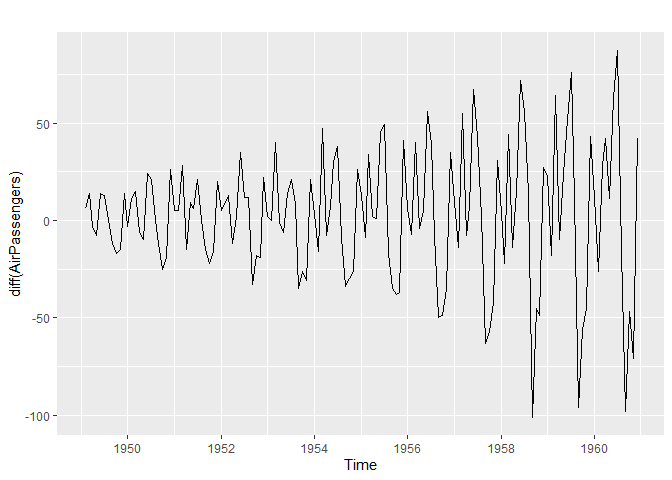

```r
autoplot(diff(AirPassengers))
```

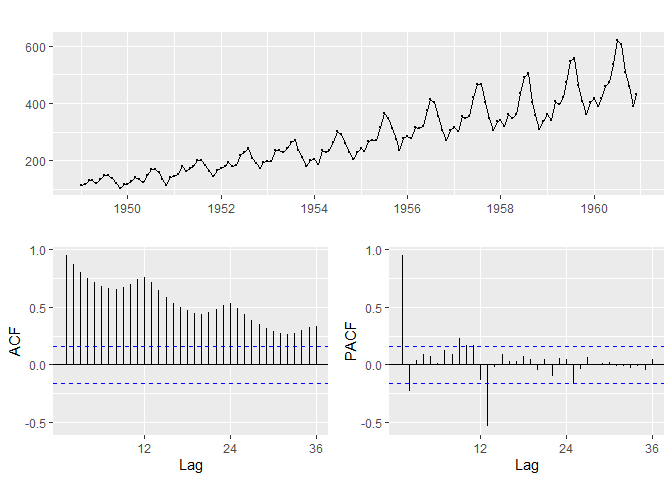

```r
ggtsdisplay(AirPassengers)
```

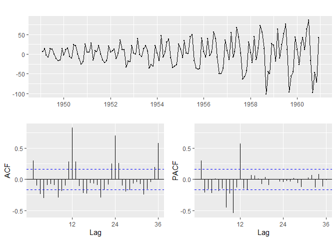

```r
ggtsdisplay(diff(AirPassengers))
```

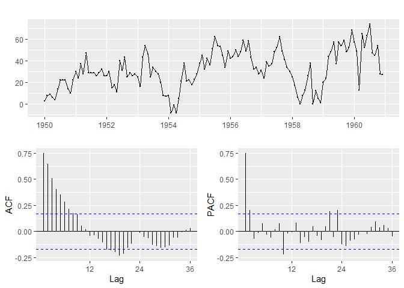

```r
ggtsdisplay(diff(AirPassengers,12))
```

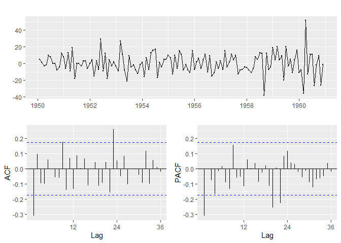

```r
ggtsdisplay(diff(diff(AirPassengers,12)))
```

```r
AirPassengers
```

```
##      Jan Feb Mar Apr May Jun Jul Aug Sep Oct Nov Dec
## 1949 112 118 132 129 121 135 148 148 136 119 104 118
## 1950 115 126 141 135 125 149 170 170 158 133 114 140
## 1951 145 150 178 163 172 178 199 199 184 162 146 166
## 1952 171 180 193 181 183 218 230 242 209 191 172 194
## 1953 196 196 236 235 229 243 264 272 237 211 180 201
## 1954 204 188 235 227 234 264 302 293 259 229 203 229
## 1955 242 233 267 269 270 315 364 347 312 274 237 278
## 1956 284 277 317 313 318 374 413 405 355 306 271 306
## 1957 315 301 356 348 355 422 465 467 404 347 305 336
## 1958 340 318 362 348 363 435 491 505 404 359 310 337
## 1959 360 342 406 396 420 472 548 559 463 407 362 405
## 1960 417 391 419 461 472 535 622 606 508 461 390 432
```

```r
diff(AirPassengers,12)
```

```
##      Jan Feb Mar Apr May Jun Jul Aug Sep Oct Nov Dec
## 1950   3   8   9   6   4  14  22  22  22  14  10  22
## 1951  30  24  37  28  47  29  29  29  26  29  32  26
## 1952  26  30  15  18  11  40  31  43  25  29  26  28
## 1953  25  16  43  54  46  25  34  30  28  20   8   7
## 1954   8  -8  -1  -8   5  21  38  21  22  18  23  28
## 1955  38  45  32  42  36  51  62  54  53  45  34  49
## 1956  42  44  50  44  48  59  49  58  43  32  34  28
## 1957  31  24  39  35  37  48  52  62  49  41  34  30
## 1958  25  17   6   0   8  13  26  38   0  12   5   1
## 1959  20  24  44  48  57  37  57  54  59  48  52  68
## 1960  57  49  13  65  52  63  74  47  45  54  28  27
```

En general, se sabe que el punto de partida para el análisis en series de tiempo estacionarias. Es decir, que los datos involucrados cumplan unas exigencias mínimas:

- Ser constante en media (No tener tendencia en ninguna forma)
- Ser constante en varianza.

Si bien el criterio visual es importante para determinar el tratamiento a tomar, son necesarios criterios técnicos para tomar tales decisiones. Es así que se postulan las

## Las pruebas de raíz unitarias

- notaremos como $I(0)$ a las **Series integradas de orden 0**. Dichas series son aquellas que no presentan problemas de estacionariedad.
- notaremos como $I(1)$ a las series no estacionarías.

Así, en el caso que sea de nuestro interés saber cuándo una serie es `bien comportada` en el sentido de estacionariedad, tenemos la prueba aumentada de **Dickey-Fuller** o **Phillips- Perron** que establecerá si la serie es integrada de orden 1. Es decir, formalmente

$$\begin{cases}
H_0:y_t\sim I(1) \ \ \ \ \ \ y_t \text{ no es estacionaria }\\
H_1:y_t\sim I(0) \ \ \ \ \ \ y_t \text{ es estacionaria }
\end{cases}$$

En la práctica, se utiliza la prueba de *Dickey-Fuller aumentada* con los comandos en ,

- $\texttt{ur.df()}$ y
- $\texttt{adf.test()}$

de los paquetes $\texttt{urca}$ y $\texttt{tseries}$, respectivamente. Ahora, mientras que la prueba $\texttt{adf.test()}$ reporta directamente el p-valor de la prueba de raíz unitaria, la función $\texttt{ut.test()}$ reporta los valores de la estadística de prueba y de los valores críticos con los valores de significancia $1\%, 5\%$ y $10\%$.

## FASES

```
La metodología de Box y Jenkins se resume en cuatro fases:
```

- La primera fase consiste en **identificar** el posible modelo ARIMA que sigue la serie, lo que requiere:
  - Decidir qué transformaciones aplicar para convertir la serie observada en una serie estacionaria.
  - Determinar un modelo ARMA para la serie estacionaria, es decir, los órdenes $p$ y $q$ de su estructura autorregresiva y de media móvil.
- La segunda fase: **estimación**, En esta etapa se estiman los coeficientes de los términos autorregresivos y de media móvil incluidos en el modelo, cuyo número de rezagos $p$ y $q$ ya han sido identificados en la etapa anterior.
- La tercera fase es el **diagnostico**, donde se comprueba que los residuos no tienen estructura de dependencia y siguen un proceso de ruido blanco.
- La cuarta fase es la **predicción**, una vez que se ha obtenido un modelo adecuado se realizan predicciones con el mismo

### Identificación de un modelo

- Decidir si $x_t$ necesita ser transformada para eliminar la no estacionariedad en media o la no estacionariedad en varianza (heteroscedasticidad). Puede ser conveniente utilizar logaritmos de la serie o aplicar la transformación de Box‐Cox.
- Determinación del grado $d$ de diferenciación adecuado.

En general, la falta de estacionariedad se manifiesta en que los coeficientes de la función de autocorrelación estimada tienden a decrecer muy lentamente.

- Decidir los valores de $(p, q)$, y si existe una componente estacional, decidir los órdenes de los operadores estacionales $(P, Q)$. Para este apartado se utilizan las funciones de autocorrelación **(ACF)** y autocorrelación parcial **(PACF)** según el siguiente cuadro:

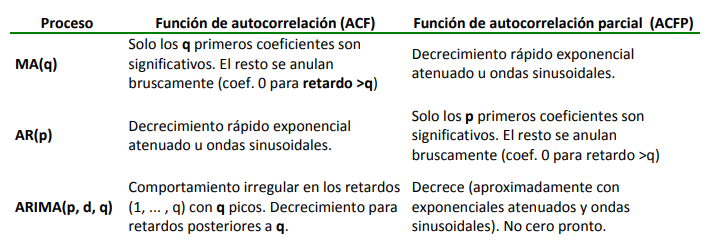

## Metodología Box Jenkins

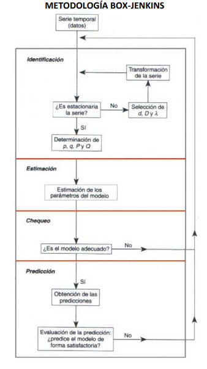